# aer13_OriginalHomeworkCode_03

Abby_Robinson

10/7/2021

#Some of My Best Friends are Zombies…

**Set working directory using setwd() function and load “zombies.csv” dataset into R**

```r
setwd("/Users/AbbyRobinson/Desktop/BIOANTHRO STATS")
zombies <- read.csv("zombies.csv", header = TRUE)
zombies
```

[output not shown]

[output cut: 1987 more lines]

##1. Calculate the population mean and standard deviation for each quantitative random variable (height, weight, age, number of zombies killed, and years of education). NOTE: You will not want to use the built in var() and sd() commands as these are for samples.

###height can you just use the mean function to get the population mean??

```r
population_mean_height <- mean(zombies$height)
population_mean_height
```

```
## [1] 67.6301
```

Calculating population standard deviation

```r
x <- zombies$height

pop_v <- function(x) {
    sum((x - mean(x))^2)/(length(x))
}

pop_sd <- function(x) {
    sqrt(pop_v(x))
}
pop_sd(x)
```

```
## [1] 4.30797
```

###weight

mean

```r
population_mean_weight <- mean(zombies$weight)
population_mean_weight
```

```
## [1] 143.9075
```

standard deviation

```r
x <- zombies$weight
pop_sd(x)
```

```
## [1] 18.39186
```

###age

mean

```r
population_mean_age <- mean(zombies$age)
population_mean_age
```

```
## [1] 20.04696
```

standard deviation

```r
x <- zombies$age
pop_sd(x)
```

```
## [1] 2.963583
```

###number of zombies killed

mean

```r
population_mean_zombies_killed <- mean(zombies$zombies_killed)
population_mean_zombies_killed
```

```
## [1] 2.992
```

standard deviation

```r
x <- zombies$zombies_killed
pop_sd(x)
```

```
## [1] 1.747551
```

###years of education

mean

```r
population_mean_years_of_education <- mean(zombies$years_of_education)
population_mean_years_of_education
```

```
## [1] 2.996
```

standard deviation

```r
x <- zombies$years_of_education
pop_sd(x)
```

```
## [1] 1.675704
```

##2. Use {ggplot} to make boxplots of each of these variables by gender.

```r
library(ggplot2)
zom.height <- zombies$height
```

###height

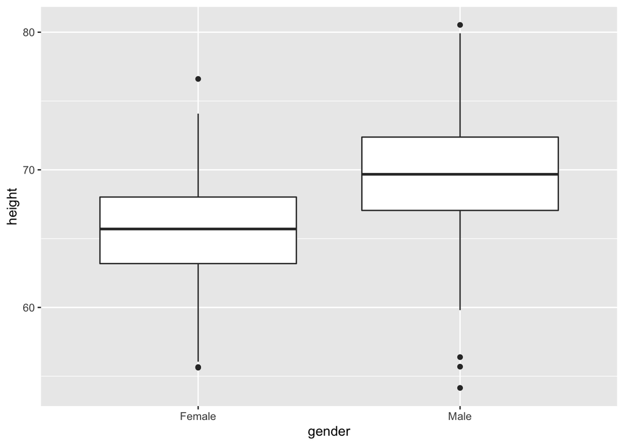

```r
z <- ggplot(data = zombies, aes(x = gender, y = height))
z <- z + geom_boxplot()

z
```

###weight

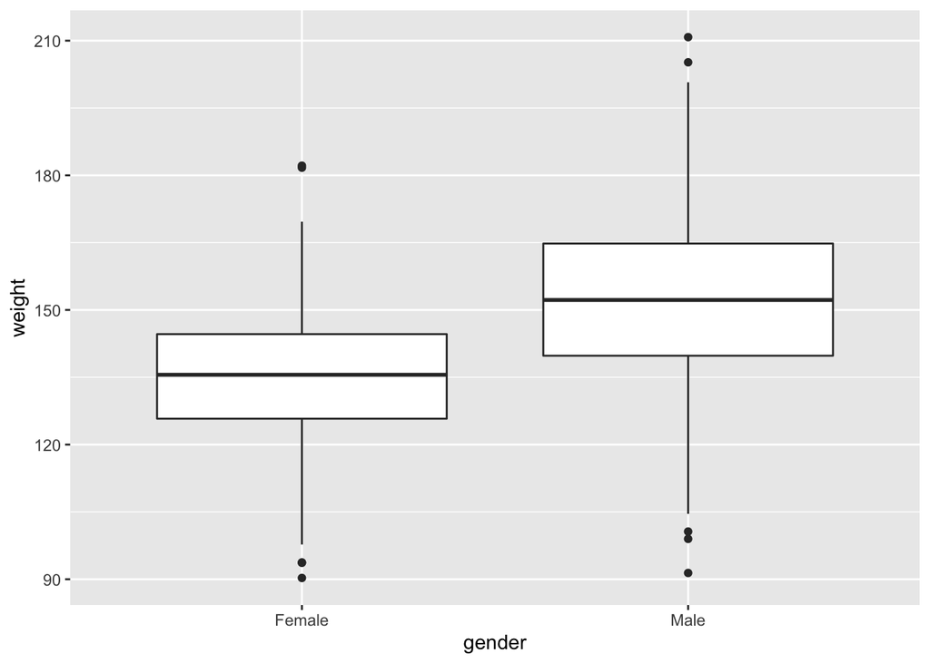

```r
z <- ggplot(data = zombies, aes(x = gender, y = weight))
z <- z + geom_boxplot()

z
```

###age

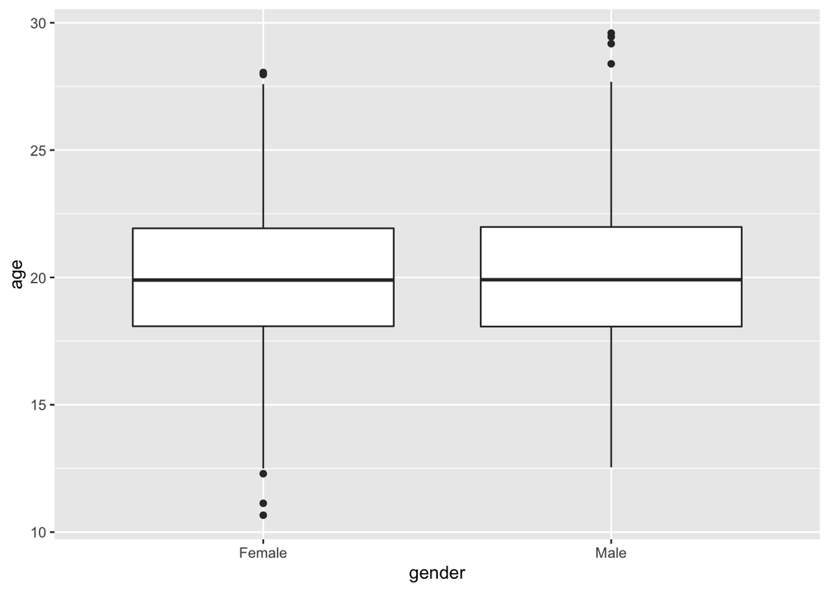

```r
z <- ggplot(data = zombies, aes(x = gender, y = age))
z <- z + geom_boxplot()

z
```

###number of zombies killed

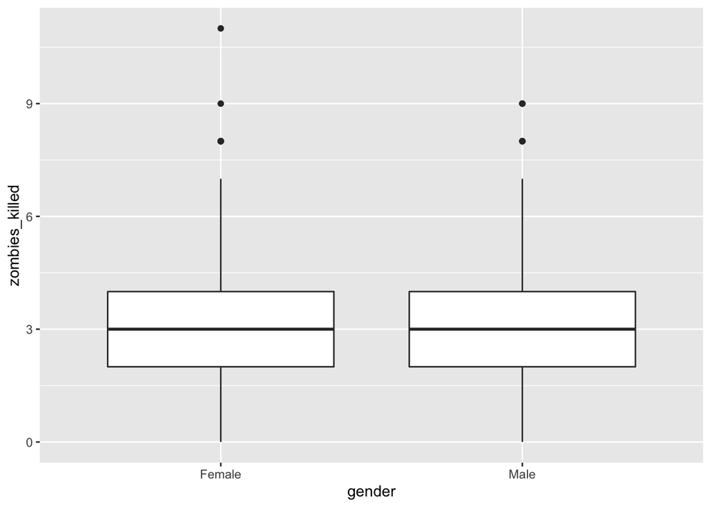

```r
z <- ggplot(data = zombies, aes(x = gender, y = zombies_killed))
z <- z + geom_boxplot()

z
```

###years of education

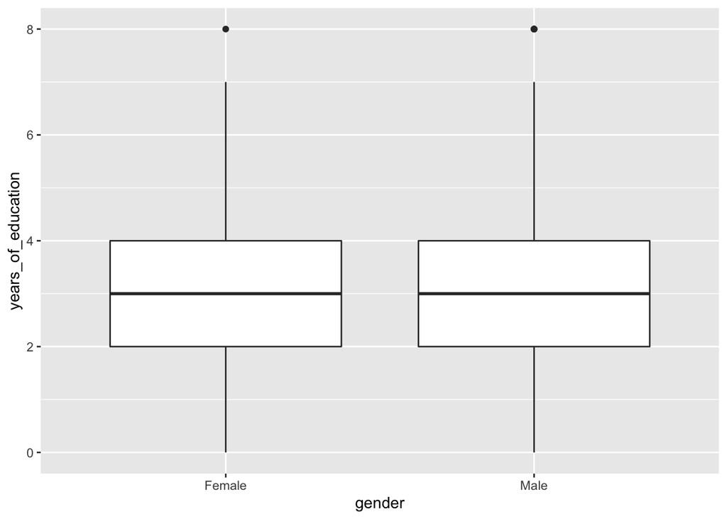

```r
z <- ggplot(data = zombies, aes(x = gender, y = years_of_education))
z <- z + geom_boxplot()

z
```

##3. Use {ggplot} to make scatterplots of height and weight in relation to age. Do these variables seem to be related? In what way?

###height

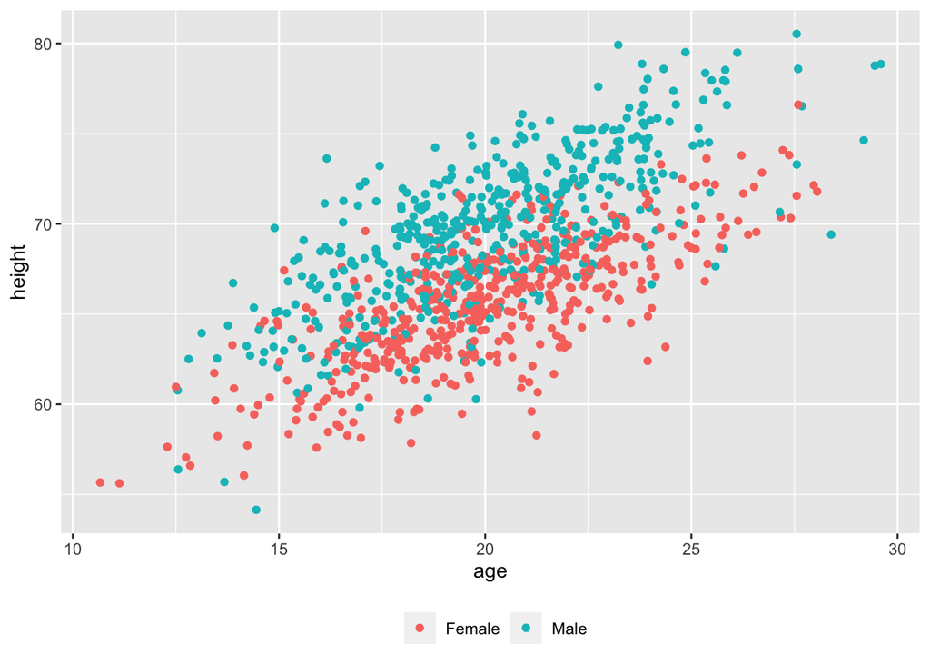

```r
z <- ggplot(data = zombies, aes(x = age, y = height, color = factor(gender)))
z <- z + geom_point()
z <- z + theme(legend.position = "bottom", legend.title = element_blank())
z
```

###weight

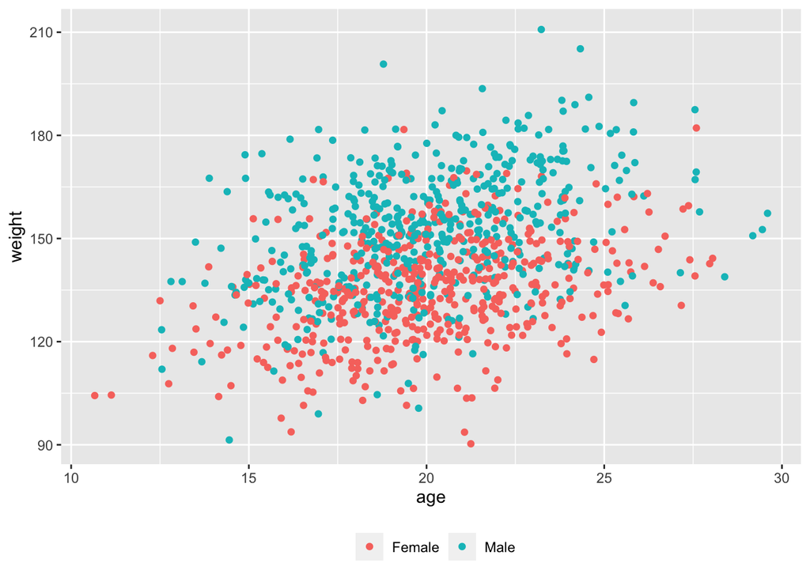

```r
z <- ggplot(data = zombies, aes(x = age, y = weight, color = factor(gender)))
z <- z + geom_point()
z <- z + theme(legend.position = "bottom", legend.title = element_blank())
z
```

both the height and the weight plots show a direct, positive relationship between age and height, and age and weight. I found it surprising that there seems to be a stronger relationship between age and height than there is for age and weight… I would expect there to be a stronger relationship between age and height in people’s 20’s because humans don’t usually grow taller after like 18…. or maybe thats just me…

##4. Using histograms and Q-Q plots, check whether the quantitative variables seem to be drawn from a normal distribution. Which seem to be and which do not (hint: not all are drawn from the normal distribution)? For those that are not normal, can you determine from which common distribution they are drawn?

###height

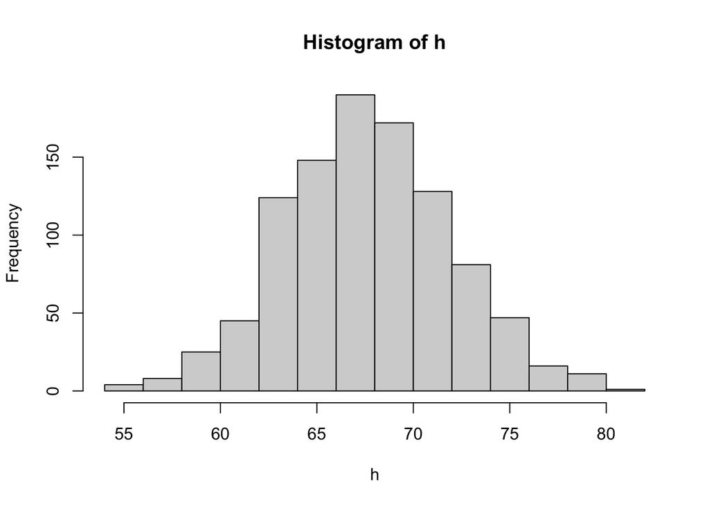

```r
h <- zombies$height
hist(h) #histogram shows a normal distribution around the mean
```

```r
population_mean_height
```

```
## [1] 67.6301
```

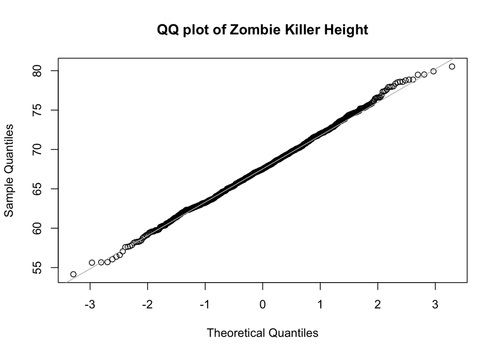

```r
qqnorm(h, main = "QQ plot of Zombie Killer Height")
qqline(h, col = "gray") #normally distributed
```

###weight

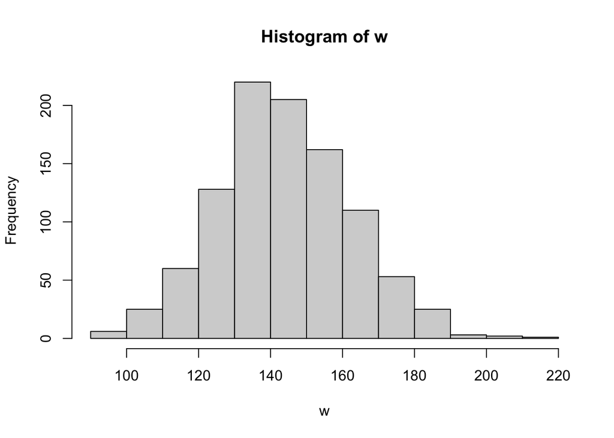

```r
w <- zombies$weight
hist(w) #histogram shows a normal distribution around the mean
```

```r
population_mean_weight
```

```
## [1] 143.9075
```

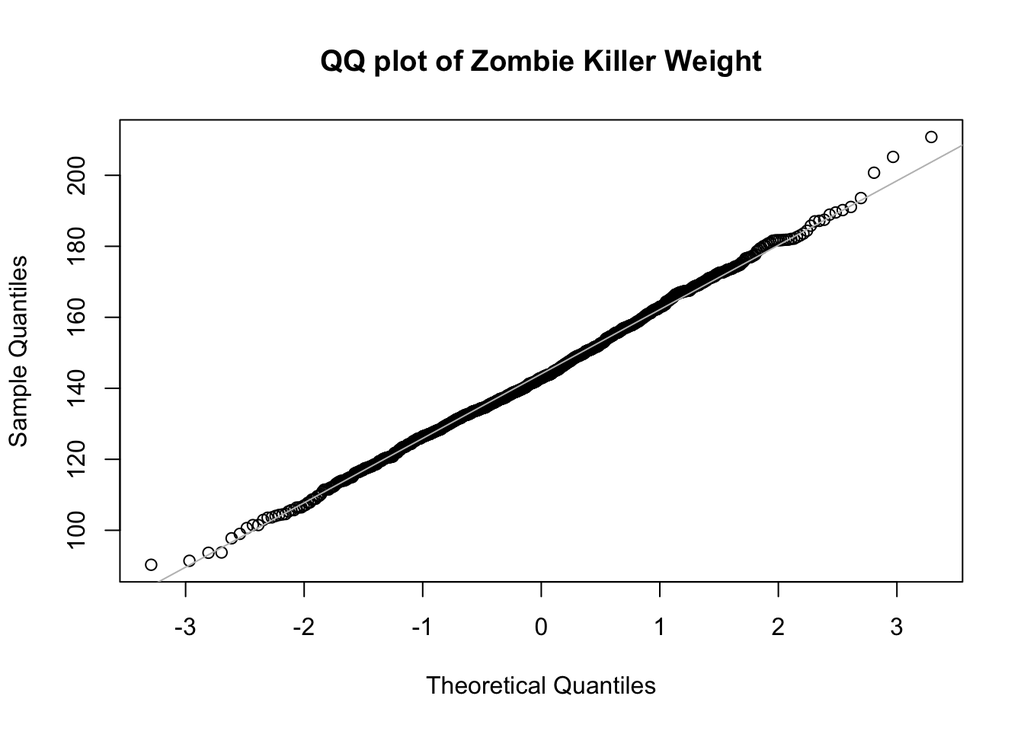

```r
qqnorm(w, main = "QQ plot of Zombie Killer Weight")
qqline(w, col = "gray") #normally distributed
```

###age

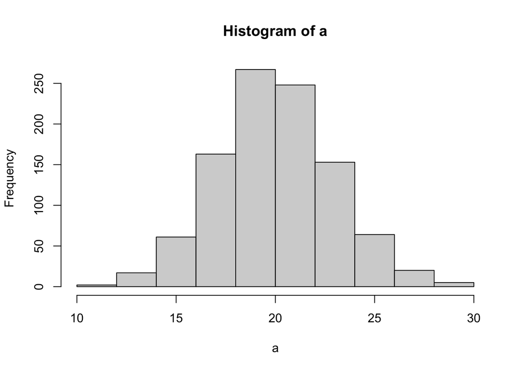

```r
a <- zombies$age
hist(a) #histogram shows a normal distribution around the mean
```

```r
population_mean_age
```

```
## [1] 20.04696
```

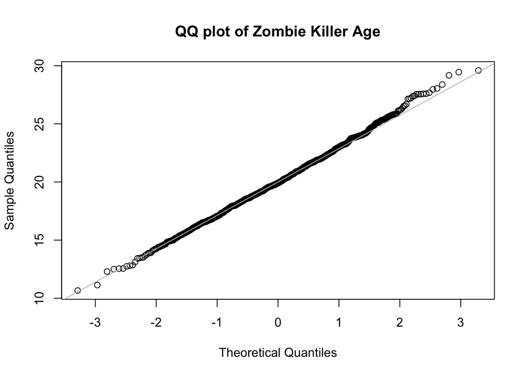

```r
qqnorm(a, main = "QQ plot of Zombie Killer Age")
qqline(a, col = "gray") #normally distributed
```

###number of zombies killed

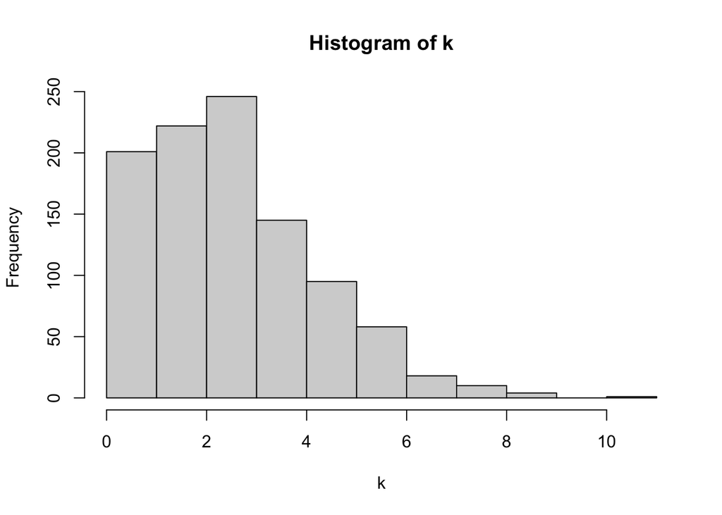

```r
k <- zombies$zombies_killed
hist(k) #histogram is skewed towards lower numbers
```

```r
population_mean_zombies_killed
```

```
## [1] 2.992
```

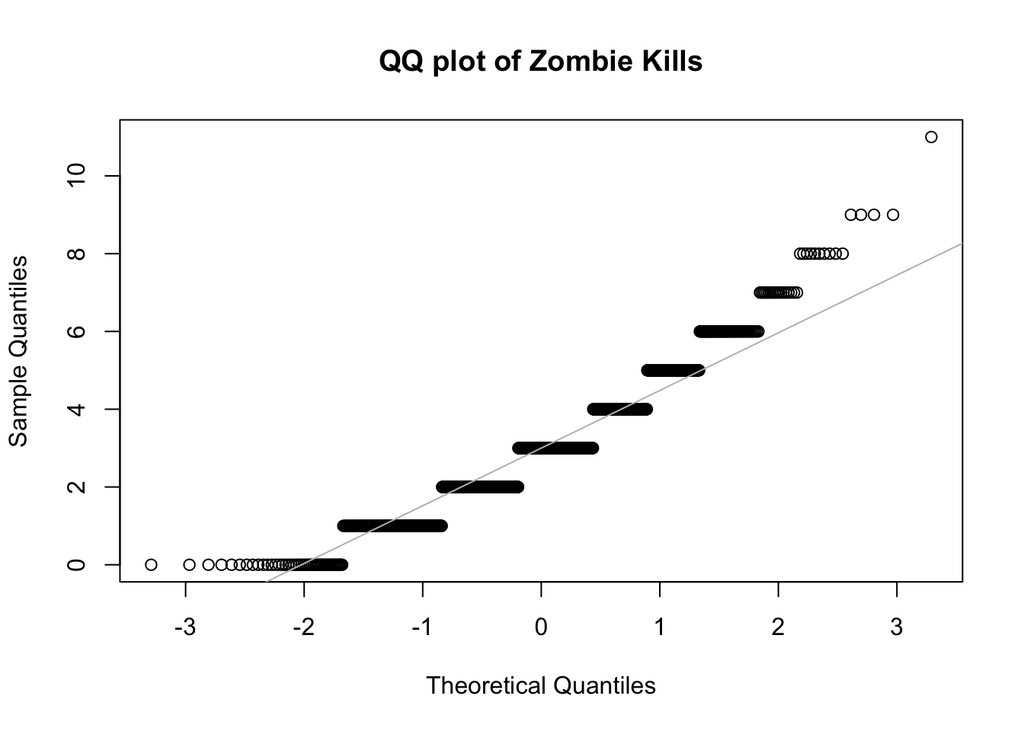

```r
qqnorm(k, main = "QQ plot of Zombie Kills")
qqline(k, col = "gray") #WOAH!! super weird!
```

###years of education

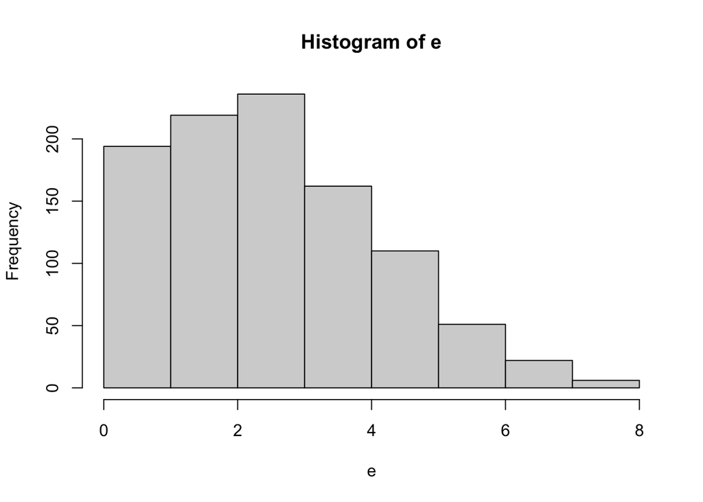

```r
e <- zombies$years_of_education
hist(e) #histogram is skewed towards lower numbers
```

```r
population_mean_years_of_education
```

```
## [1] 2.996
```

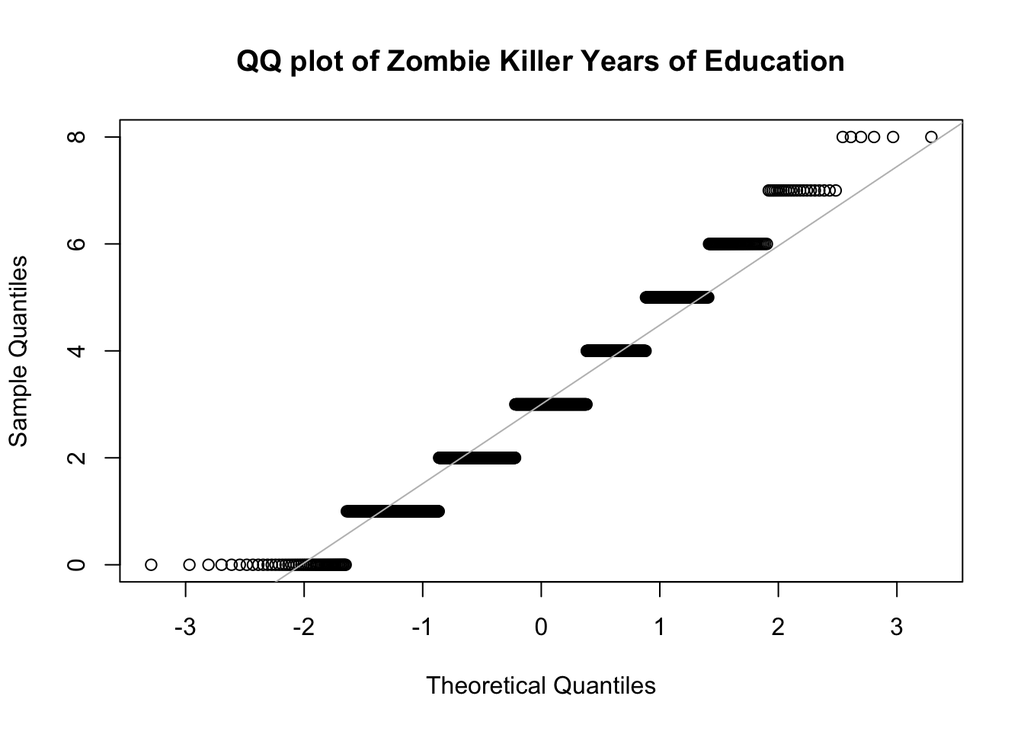

```r
qqnorm(e, main = "QQ plot of Zombie Killer Years of Education")
qqline(e, col = "gray") #QQplot looks just like plot zombie kills
```

##For those that are not normal, can you determine from which common distribution they are drawn?

number of zombies killed and years of education are not normal because these data are not random. To determine from which common distribution they are drawn, you can look at the data itself…

```r
zombies$zombies_killed
```

```
##    [1]  2  5  1  5  4  1  0  4  9  2  4  4  2  5  4  2  5  3  2  1  3  1  0  3
##   [25]  8  1  1  1  4  1  1  1  3  2  5  3  8  1  3  8  7  7  7  1  3  2  7  2
##   [49]  2  6  6  2  1  1  3  7  3  5  6  3  4  3  1  1  4  3  1  1  1  3  2  4
##   [73]  3  4  2  3  3  0  4  1  1  2  4  3  3  4  6  2  2  3  5  4  9  3  4  1
##   [97]  2  2  2  5  3  3  0  3  4  4  3  1  5  6  3  5  3  2  6  3  2  2  2  4
##  [121]  1  4  3  1  3  4  5  5  2  3  2  6  3  5  4  1  1  3  2  1  3  4  4  7
##  [145]  5  1  0  3  3  2  1  0  5  3  3  1  2  4  4  4  5  2  2  5  5  3  6  6
##  [169]  2  4  2  4  5  3  3  4  3  2  3  4  2  4  1  2  4  3  2  5  4  1  1  4
##  [193]  5  3  2  6  4  2  0  1  6  3  2  5  2  4  6  4  4  2  1  4  4  7  5  2
##  [217]  0  2  2  4  5  2  3  2  3  3  0  1  0  3  2  2  4  6  4  4  1  3  3  5
##  [241]  2  2  3  3  3  4  3  1  3  3  2  7  1  0  2  5  4  3  7  1  4  1  0  3
##  [265]  5  3  3  3  8  2  3  2  2  3  3  3  3  7  6  2  4  3  1  3  1  6  2  6
##  [289]  4  0  1  3  2  1  3  6  2  6  5  4  3  0  1  3  1  1  4  2  2  4  2  2
##  [313]  5  2  5  3  3  2  0  2  3  3  1  4  2  3  3  4  1  6  4  2  6  2  1  2
##  [337]  3  5  4  9  1  2  1  3  8  5  2  3  3  1  4  2  1  2  2  2  4  2  4  1
```

[output cut: 27 more lines]

```r
zombies$years_of_education
```

```
##    [1] 1 3 1 6 3 4 4 0 3 3 4 3 1 5 5 2 1 5 1 5 1 2 5 3 0 3 2 2 2 1 1 0 2 2 4 2 4
##   [38] 3 3 6 3 4 2 3 1 3 1 1 7 2 2 0 3 0 4 3 4 2 6 1 2 2 3 3 0 1 3 4 2 3 3 2 2 5
##   [75] 2 3 5 2 2 2 1 2 4 6 3 2 4 3 5 3 3 1 4 3 4 3 1 2 1 2 7 3 2 5 3 6 2 0 5 1 2
##  [112] 1 3 3 1 1 3 4 1 2 4 3 3 1 4 5 3 2 3 1 2 6 1 3 1 6 4 2 3 3 2 4 1 2 4 2 1 2
##  [149] 8 5 3 2 1 1 2 2 3 0 2 4 1 1 2 2 2 2 3 4 4 5 5 4 3 2 6 7 1 2 1 4 3 5 4 5 2
##  [186] 1 1 3 0 4 1 0 2 3 5 4 3 4 1 0 0 2 2 3 2 2 3 4 3 1 3 3 0 4 4 3 7 2 4 3 5 1
##  [223] 4 3 4 6 6 1 3 4 5 4 1 2 4 1 3 4 2 3 3 1 1 2 2 0 3 2 4 5 4 4 3 6 4 3 1 2 4
##  [260] 3 1 2 2 3 4 0 3 3 2 2 3 3 3 2 5 4 2 4 1 7 3 3 0 4 5 7 3 4 3 3 2 1 3 5 1 3
##  [297] 2 4 2 5 4 4 1 3 4 1 1 0 4 4 3 3 0 1 4 2 5 5 2 5 2 6 3 3 2 3 3 6 1 3 1 1 2
##  [334] 3 2 1 6 3 7 1 4 8 2 3 1 2 6 3 0 6 4 7 7 2 2 4 3 1 2 3 6 1 6 5 3 3 2 2 3 5
##  [371] 1 1 5 3 5 3 2 4 4 1 3 5 5 1 1 3 4 1 1 4 5 3 2 4 3 1 5 3 2 3 3 6 0 3 1 2 2
##  [408] 3 2 2 0 2 8 2 3 1 3 5 2 5 3 4 0 4 0 3 5 1 2 6 3 5 2 3 3 2 2 4 5 0 2 6 3 3
##  [445] 2 5 3 1 2 3 1 3 3 4 1 3 1 6 5 5 4 3 4 5 3 3 7 4 3 4 2 2 4 6 3 2 1 4 5 4 3
##  [482] 3 1 1 4 3 3 2 7 1 2 2 4 0 2 2 2 1 3 4 4 3 1 3 2 4 6 5 5 2 2 2 2 4 2 2 0 6
##  [519] 5 7 2 3 2 4 3 3 6 0 4 4 2 1 7 2 6 2 5 4 2 2 3 6 4 2 0 3 3 1 5 5 5 5 3 3 5
##  [556] 4 4 0 3 4 2 1 4 2 2 4 1 1 2 1 2 2 0 2 2 1 2 7 2 4 4 5 5 2 5 3 3 1 1 1 4 1
##  [593] 5 3 4 3 0 3 6 1 3 2 2 1 0 6 3 5 2 1 5 4 4 0 1 3 3 7 1 3 2 4 5 3 2 5 4 1 2
##  [630] 2 0 2 2 5 7 3 2 2 6 0 3 2 2 1 2 1 2 7 4 3 3 5 6 2 4 4 2 5 1 5 2 5 2 4 2 4
##  [667] 5 2 2 4 3 5 5 2 4 6 2 5 3 4 4 1 4 6 2 5 1 7 2 1 1 3 3 3 4 2 1 2 4 5 3 3 1
##  [704] 2 6 2 5 5 2 3 5 3 2 1 3 5 0 3 3 6 3 6 3 2 1 2 2 3 3 2 4 3 2 2 5 4 5 2 4 3
##  [741] 0 1 0 5 3 4 1 4 3 4 4 4 3 0 0 2 4 5 4 2 5 4 1 2 2 2 3 1 4 4 1 2 1 4 4 5 3
##  [778] 2 4 1 3 4 0 4 3 2 3 2 4 7 6 4 6 1 3 2 2 4 2 3 3 3 1 4 2 2 7 1 3 4 3 8 3 3
##  [815] 5 3 3 8 0 2 0 2 5 7 2 1 2 3 3 2 3 3 1 5 2 3 3 6 1 4 4 4 2 3 2 4 6 6 5 5 5
##  [852] 2 1 3 3 3 3 4 4 4 3 2 5 1 1 1 1 4 4 3 2 7 2 6 1 3 3 3 2 4 0 4 5 3 3 2 2 4
##  [889] 3 3 6 1 4 1 2 4 3 2 3 2 2 1 5 3 4 4 2 6 3 5 1 2 3 5 3 4 2 2 4 4 6 1 3 3 5
##  [926] 2 0 5 5 0 3 1 4 3 4 4 5 4 5 5 6 3 5 1 1 2 6 1 4 5 5 3 2 2 3 1 4 1 4 0 1 5
##  [963] 3 4 0 3 5 2 3 3 5 3 2 5 3 2 3 6 3 3 3 1 3 0 4 3 5 2 6 0 5 5 6 4 8 2 2 3 3
## [1000] 1
```

these data are independent counts of integer numbers, which would follow the Poisson distribution

##5. Now use the sample() function to sample ONE subset of 30 zombie survivors (without replacement) from this population and calculate the mean and sample standard deviation for each variable.

###height

```r
?sample()
zombies
```

[output not shown]

[output cut: 1987 more lines]

```r
sample_height <- sample(zombies$height, size = 30, replace = FALSE, prob = NULL)
sample_height
```

```
##  [1] 65.41633 71.99679 68.19738 71.43294 68.39093 61.95252 72.98792 63.38425
##  [9] 64.27576 69.14784 65.21890 64.72491 67.05393 66.70976 70.46825 60.67610
## [17] 72.25866 67.69933 69.06732 64.99637 68.64705 63.39950 74.74845 66.03250
## [25] 70.94190 71.95263 64.40456 67.38948 59.95642 70.08365
```

```r
mean(sample_height)
```

```
## [1] 67.45374
```

```r
sd(sample_height)
```

```
## [1] 3.761755
```

##Also estimate the standard error for each variable, and construct the 95% confidence interval for each mean. Note that for the variables that are not drawn from the normal distribution, you may need to base your estimate of the CIs on slightly different code than for the normal…

standard error

```r
se_height <- (sd(sample_height)/sqrt(30))
se_height
```

```
## [1] 0.6867993
```

construct 95% confidence interval for the mean

```r
x <- sample_height
m <- mean(sample_height)

normalCI = function(x, CIlevel = 0.95) {
    upper = m + qnorm(1 - (1 - CIlevel)/2) * sqrt(var(x)/length(x))
    lower = m + qnorm((1 - CIlevel)/2) * sqrt(var(x)/length(x))
    ci <- c(lower, upper)
    return(ci)
}
normalCI(x, 0.95)
```

```
## [1] 66.10764 68.79985
```

###weight

create sample

```r
sample_weight <- sample(zombies$weight, size = 30, replace = FALSE, prob = NULL)
sample_weight
```

```
##  [1] 140.2724 120.4027 150.4619 180.1173 171.0235 151.4956 137.1840 171.5612
##  [9] 156.9905 149.9921 132.8239 135.3092 134.6127 148.9489 160.9350 133.5072
## [17] 144.1897 137.0728 148.5754 146.7831 155.7613 131.4980 189.5286 127.7302
## [25] 159.8520 142.8512 172.4352 145.7219 164.3918 177.6908
```

mean

```r
mean(sample_weight)
```

```
## [1] 150.6573
```

standard deviation

```r
sd(sample_weight)
```

```
## [1] 17.03786
```

standard error

```r
se_weight <- (sd(sample_weight)/sqrt(30))
se_weight
```

```
## [1] 3.110674
```

95% Confidence Interval

```r
x <- sample_weight
m <- mean(sample_weight)
normalCI(x, 0.95)
```

```
## [1] 144.5605 156.7542
```

###age

create sample

```r
sample_age <- sample(zombies$age, size = 30, replace = FALSE, prob = NULL)
sample_age
```

```
##  [1] 20.64774 18.66175 19.03215 26.71144 22.35030 18.83810 14.95027 23.76757
##  [9] 19.94330 17.00379 18.88307 16.15942 21.04131 15.18804 20.79042 20.42065
## [17] 19.74716 18.79596 24.03626 21.31904 19.17092 20.37872 18.92234 19.91682
## [25] 21.02118 21.10963 21.68061 24.24839 23.83751 19.50424
```

mean

```r
mean(sample_age)
```

```
## [1] 20.26927
```

standard deviation

```r
sd(sample_age)
```

```
## [1] 2.640965
```

standard error

```r
se_age <- (sd(sample_age)/sqrt(30))
se_age
```

```
## [1] 0.4821721
```

95% Confidence Interval

```r
x <- sample_age
m <- mean(sample_age)
normalCI(x, 0.95)
```

```
## [1] 19.32423 21.21431
```

###number of zombies killed

create sample

```r
sample_zombies_killed <- sample(zombies$zombies_killed, size = 30, replace = FALSE, prob = NULL)
sample_zombies_killed
```

```
##  [1] 3 7 2 2 0 2 2 2 4 4 2 3 4 1 4 2 0 6 1 4 3 2 0 1 3 4 0 4 3 2
```

mean

```r
mean(sample_zombies_killed)
```

```
## [1] 2.566667
```

standard deviation

```r
sd(sample_zombies_killed)
```

```
## [1] 1.695498
```

standard error

```r
se_zombies_killed <- (sd(sample_zombies_killed)/sqrt(30))
se_zombies_killed
```

```
## [1] 0.3095541
```

95% Confidence Interval

Write function to calculate confidence intervals under Poisson Distribution

```r
x <- mean(sample_zombies_killed)


poisson95CI = function(x) {
    upper = x + 1.96*(sqrt(x/30))
    lower = x - 1.96*(sqrt(x/30))
    ci <- c(lower, upper)
    return(ci)
}

poisson95CI(x)
```

```
## [1] 1.993369 3.139964
```

###years of education create sample

```r
sample_years_of_education <- sample(zombies$years_of_education, size = 30, replace = FALSE, prob = NULL)
sample_years_of_education
```

```
##  [1] 3 5 6 5 4 2 6 6 4 1 2 1 4 1 2 2 3 0 2 5 2 3 7 2 3 2 4 3 3 2
```

mean

```r
mean(sample_years_of_education)
```

```
## [1] 3.166667
```

standard deviation

```r
sd(sample_years_of_education)
```

```
## [1] 1.743626
```

standard error

```r
se_years_of_education <- (sd(sample_years_of_education)/sqrt(30))
se_years_of_education
```

```
## [1] 0.318341
```

95% Confidence Interval

```r
x <- mean(sample_years_of_education)
poisson95CI(x)
```

```
## [1] 2.529876 3.803457
```

##6. Now draw 99 more random samples of 30 zombie apocalypse survivors, and calculate the mean for each variable for each of these samples. Together with the first sample you drew, you now have a set of 100 means for each variable (each based on 30 observations), which constitutes a sampling distribution for each variable.

###height

```r
set <- NULL
n <- zombies$height
for (i in 1:99) {
    set[i] <- mean(sample(n, size = 30, replace = FALSE, prob = NULL))
}
sampling_distribution <- set[]
sampling_distribution
```

```
##  [1] 67.66499 67.33286 66.34515 67.28195 67.52882 66.13550 67.54427 67.34214
##  [9] 66.98160 67.33419 67.93863 68.44588 67.60573 68.38210 67.95056 67.74105
## [17] 67.51534 68.43580 67.26246 68.32925 67.31780 67.07965 67.03060 66.93349
## [25] 67.23952 66.51938 67.79674 66.86889 68.63206 67.89401 66.93441 68.37848
## [33] 67.46383 67.47894 66.62970 67.54178 68.42439 67.41430 68.27543 66.89501
## [41] 68.50906 67.28829 67.11508 68.30340 67.32084 67.12137 65.87189 68.30688
## [49] 68.72451 67.46477 67.84105 68.08949 66.92861 67.66376 68.27239 69.65894
## [57] 68.01939 66.70910 67.43783 67.39292 67.81693 68.52213 66.63177 67.78433
## [65] 66.32505 67.90152 67.54558 67.07488 68.19945 67.24248 68.74216 67.02100
## [73] 66.78898 68.47757 66.91125 67.84155 68.38569 66.29636 66.34803 67.56503
## [81] 66.85272 67.45308 68.39046 67.33516 66.61577 67.42597 67.61401 67.88022
## [89] 67.67468 66.66107 67.42131 68.06641 68.22512 66.94073 68.07784 66.93460
## [97] 68.53079 67.65818 67.78220
```

##What are the means and standard deviations of this distribution of means for each variable? How do the standard deviations of means compare to the standard errors estimated in [5]? What do these sampling distributions look like (a graph might help here)? Are they normally distributed? What about for those variables that you concluded were not originally drawn from a normal distribution?

```r
mean(sampling_distribution)
```

```
## [1] 67.54392
```

```r
sd(sampling_distribution)
```

```
## [1] 0.6837934
```

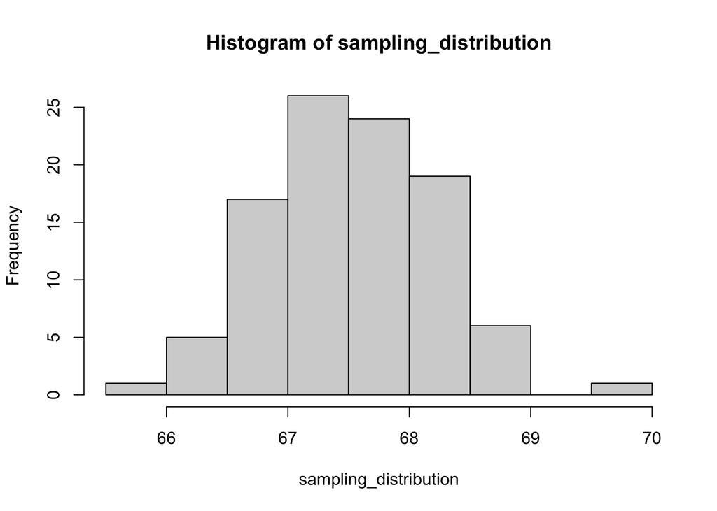

```r
hist(sampling_distribution) #looks like a normal distrubution
```

###weight

```r
set <- NULL
n <- zombies$weight
for (i in 1:99) {
    set[i] <- mean(sample(n, size = 30, replace = FALSE, prob = NULL))
}
sampling_distribution <- set[]
sampling_distribution
```

```
##  [1] 143.6087 143.1462 148.8056 143.6810 142.5815 144.1803 143.6894 144.7438
##  [9] 147.3848 138.7701 146.1971 146.2378 148.7851 141.4449 142.8624 144.6369
## [17] 145.4661 143.8702 139.0650 147.8963 146.3854 152.2695 145.2874 143.2971
## [25] 150.2317 141.9123 140.6645 142.2878 143.8372 149.3987 143.7693 144.7400
## [33] 142.3920 144.0364 147.2153 145.3394 144.6213 147.1417 143.1792 144.1875
## [41] 143.5918 144.3739 143.7174 146.4976 143.9865 139.1702 146.8933 145.4371
## [49] 140.3368 145.4298 138.1235 144.3892 142.1518 143.6753 142.4748 145.8275
## [57] 141.1049 142.5556 143.1693 144.5020 145.3899 148.0103 144.6877 146.3267
## [65] 140.5964 146.4978 144.1058 141.0295 139.1830 146.1862 144.0974 141.4169
## [73] 148.0713 142.7655 144.1521 141.3825 145.4604 141.9029 145.5611 146.7772
## [81] 141.1003 142.4433 145.6058 145.6199 146.7867 148.7214 143.4185 142.2014
## [89] 138.9104 143.8815 147.2292 145.5480 138.7224 138.2582 140.7247 144.8321
## [97] 147.4109 146.1259 140.4328
```

```r
mean(sampling_distribution)
```

```
## [1] 144.1235
```

```r
sd(sampling_distribution)
```

```
## [1] 2.790659
```

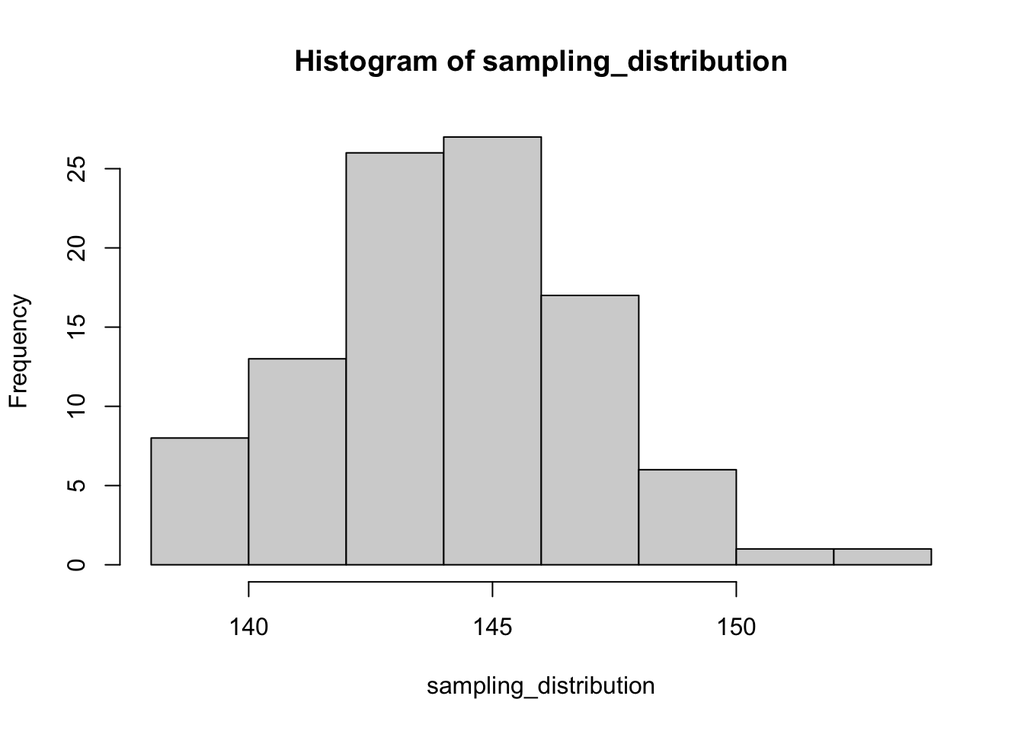

```r
hist(sampling_distribution) #looks like a normal distribution
```

###age

```r
set <- NULL
n <- zombies$age
for (i in 1:99) {
    set[i] <- mean(sample(n, size = 30, replace = FALSE, prob = NULL))
}
sampling_distribution <- set[]
sampling_distribution
```

```
##  [1] 20.37370 19.54602 21.46203 19.54189 20.26964 20.60664 19.69209 19.55401
##  [9] 20.29369 21.72273 19.62684 20.36496 20.85965 19.50501 19.68289 20.49927
## [17] 20.61962 20.52508 19.80527 19.48044 19.75518 20.49398 20.88610 19.74148
## [25] 20.40507 19.89925 20.05013 20.30257 19.97675 19.63674 19.28217 20.12325
## [33] 20.29331 19.37328 20.05332 20.24005 18.67336 20.69277 20.26955 20.93409
## [41] 20.78955 19.11020 20.25709 19.70566 20.00422 20.19848 20.51484 19.52746
## [49] 20.54915 19.81355 20.02271 20.03297 19.28432 19.60725 19.38853 19.89451
## [57] 19.74946 20.41601 19.79630 19.71568 19.99296 19.17681 20.76029 19.61397
## [65] 19.74689 19.98840 19.76274 19.10561 20.13753 19.69830 20.72494 20.52053
## [73] 19.58527 19.07157 19.63118 20.09203 20.31073 20.12049 18.92548 19.74723
## [81] 19.15559 19.86343 19.84011 19.89292 20.20302 19.76445 19.27521 19.42902
## [89] 20.58534 19.97376 20.47752 20.06128 19.77159 21.03771 20.69376 20.16563
## [97] 20.62175 20.12689 20.10102
```

```r
mean(sampling_distribution)
```

```
## [1] 20.01257
```

```r
sd(sampling_distribution)
```

```
## [1] 0.5418849
```

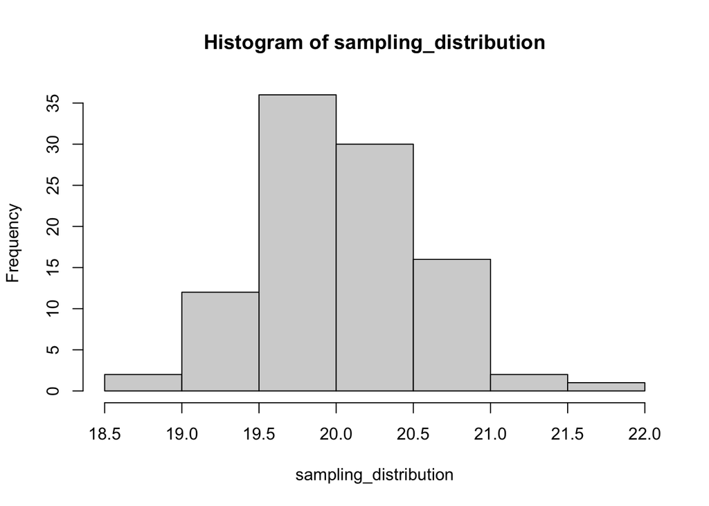

```r
hist(sampling_distribution) #looks like a normal distribution
```

###zombies killed

```r
set <- NULL
n <- zombies$zombies_killed
for (i in 1:99) {
    set[i] <- mean(sample(n, size = 30, replace = FALSE, prob = NULL))
}
sampling_distribution <- set[]
sampling_distribution
```

```
##  [1] 2.700000 3.000000 3.266667 2.766667 2.800000 2.700000 3.400000 3.333333
##  [9] 3.133333 3.466667 3.000000 3.200000 2.866667 2.700000 2.500000 2.633333
## [17] 2.800000 3.066667 3.100000 3.500000 2.966667 3.266667 3.366667 2.600000
## [25] 2.900000 3.400000 2.966667 2.833333 3.033333 2.733333 2.500000 2.833333
## [33] 3.000000 2.700000 3.566667 3.266667 2.800000 2.733333 2.833333 2.933333
## [41] 2.633333 3.366667 3.200000 3.800000 3.033333 2.833333 2.733333 2.533333
## [49] 3.300000 3.366667 3.166667 2.333333 3.066667 3.200000 3.066667 2.800000
## [57] 2.866667 2.800000 2.766667 2.866667 2.933333 3.466667 3.233333 3.433333
## [65] 2.966667 3.166667 3.033333 2.633333 3.266667 2.633333 2.666667 3.233333
## [73] 2.900000 2.766667 2.766667 3.566667 2.733333 2.733333 2.800000 3.000000
## [81] 3.133333 3.133333 3.033333 3.600000 3.366667 2.533333 3.333333 3.100000
## [89] 2.633333 3.100000 3.200000 2.866667 2.933333 3.133333 3.433333 2.800000
## [97] 3.766667 3.233333 3.033333
```

```r
mean(sampling_distribution)
```

```
## [1] 3.012121
```

```r
sd(sampling_distribution)
```

```
## [1] 0.3028008
```

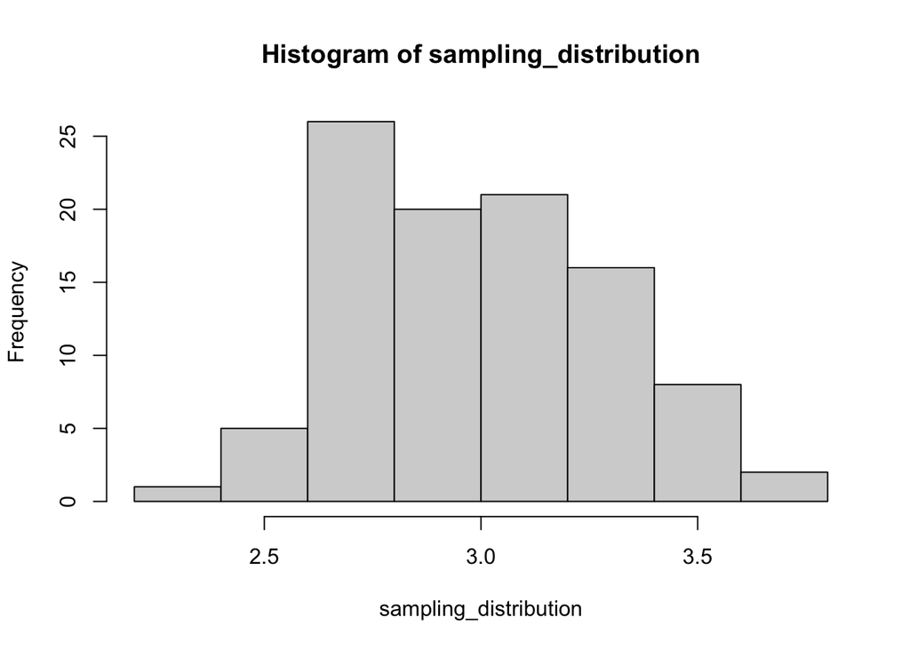

```r
hist(sampling_distribution) #looks like a normal distribution
```

###years of education

```r
set <- NULL
n <- zombies$years_of_education
for (i in 1:99) {
    set[i] <- mean(sample(n, size = 30, replace = FALSE, prob = NULL))
}
sampling_distribution <- set[]
sampling_distribution
```

```
##  [1] 2.633333 2.733333 2.800000 2.800000 3.000000 2.933333 3.033333 2.866667
##  [9] 2.800000 2.833333 2.766667 2.933333 2.566667 3.433333 3.733333 2.900000
## [17] 3.233333 3.000000 2.766667 2.866667 2.966667 3.100000 3.333333 3.366667
## [25] 2.933333 3.300000 2.666667 2.466667 2.766667 3.166667 2.566667 3.400000
## [33] 2.533333 2.833333 3.400000 3.800000 2.933333 3.066667 2.733333 3.366667
## [41] 2.833333 3.233333 2.333333 2.966667 2.900000 2.600000 3.733333 3.666667
## [49] 2.900000 3.100000 3.066667 3.200000 3.133333 2.500000 2.733333 3.466667
## [57] 2.800000 2.966667 3.000000 3.300000 2.900000 2.833333 2.733333 2.900000
## [65] 3.400000 3.066667 3.066667 2.833333 3.166667 2.800000 3.466667 3.200000
## [73] 2.866667 3.133333 2.700000 2.966667 3.033333 2.700000 3.166667 2.900000
## [81] 3.033333 2.933333 3.266667 2.800000 2.866667 3.200000 2.733333 2.766667
## [89] 3.000000 3.000000 2.966667 2.966667 2.933333 3.000000 2.700000 2.966667
## [97] 2.966667 2.833333 3.033333
```

```r
mean(sampling_distribution)
```

```
## [1] 2.985522
```

```r
sd(sampling_distribution)
```

```
## [1] 0.2795429
```

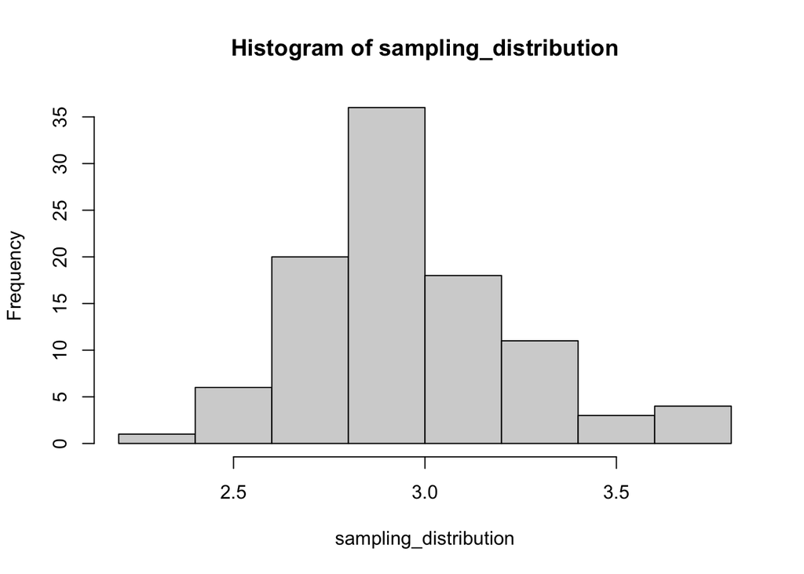

```r
hist(sampling_distribution) #looks like a normal distribution
```

Challenges:

5. Error in sample.int(length(x), size, replace, prob) : cannot take a sample larger than the population when ‘replace = FALSE’

original code: sample(zombies, size = 30, replace = FALSE, prob = NULL), needed to specify zombies$variable